# Simulations for individual differences in group foraging in manta rays

Author

Raphaël Royauté

Published

February 20, 2024

### 0.2 Packages Necessary

```r
# Make sure to have these packages installed before runnig the code below
library(tidyverse);  library(here); library(kableExtra); library(lme4)
library(brms); library(rptR); library(partR2); library(easystats)
library(ordinal); library(ggdist); library(tidyverse); library(ggthemes)
library(patchwork); library(tidybayes); library(visibly)
```

### 0.3 Simulate variation in leadership preferences

#### Setup and individual assignment to foraging groups

```r
# Seed for reproducible simulation
set.seed(42)

# Value storage
N_ID = 100
N_obs = 100
Group_size = 10
# Dataset structure
dfsim = data.frame(Obs = rep(1:N_obs, each = N_ID),
                   Id = rep(1:N_ID, N_obs),
                   # Sample integers from 1 to 10 and repeat 100 times
                   Group = rep(sample.int(n = Group_size, size = Group_size,
                                          replace = F), N_obs),
                   Group_N = 10) %>%
  mutate(Group_ID = paste(Group, Obs, sep = "_"))
dfsim %>% head(15) %>% kable()
```

| Obs | Id | Group | Group_N | Group_ID |
| --- | --- | --- | --- | --- |
| 1 | 1 | 1 | 10 | 1_1 |
| 1 | 2 | 5 | 10 | 5_1 |
| 1 | 3 | 10 | 10 | 10_1 |
| 1 | 4 | 8 | 10 | 8_1 |
| 1 | 5 | 2 | 10 | 2_1 |
| 1 | 6 | 4 | 10 | 4_1 |
| 1 | 7 | 6 | 10 | 6_1 |
| 1 | 8 | 9 | 10 | 9_1 |
| 1 | 9 | 7 | 10 | 7_1 |
| 1 | 10 | 3 | 10 | 3_1 |
| 1 | 11 | 1 | 10 | 1_1 |
| 1 | 12 | 5 | 10 | 5_1 |
| 1 | 13 | 10 | 10 | 10_1 |
| 1 | 14 | 8 | 10 | 8_1 |
| 1 | 15 | 2 | 10 | 2_1 |

```r
# Save data
write.csv2(dfsim, here("data/data_sim.csv"))
```

We now have each individual assigned to a foraging group. We then need to figure out a way to assign ranks corresponding to an individual’s position within the group (1: at the front, 2: second from the front, …).

#### Individual preference for position in group

The simplest way to rank individuals is to give them a preference score for belonging to the front or not according to a normal distribution. Here, we assume that this preference is sampled from a normal distribution of mean 0 and a standard deviation of 1 ($N(0, 1)$). We can store this information in a dataframe format

```r
# Seed for reproducible simulation
set.seed(42)

ID = data.frame(Id = 1:N_ID) %>%
  mutate(pref = rnorm(n(), 0, 1))
```

We then merge the column `pref` into the `dfsim` dataframe

```r
dfsim = merge(dfsim, ID)
```

Based on this preference score, we assign a rank to each individuals within each foraging observation and group. Because the way the `rank()` function works, individuals with the most negative value are more likely to get a lower rank value.

```r
set.seed(42)

dfsim = dfsim %>%
  group_by(Group_ID) %>%
  mutate(rank = rank(pref)) %>%
  arrange(Obs, Group) %>%
  ungroup()
dfsim %>% head(15) %>% kable()
```

| Id | Obs | Group | Group_N | Group_ID | pref | rank |
| --- | --- | --- | --- | --- | --- | --- |
| 1 | 1 | 1 | 10 | 1_1 | 1.3709584 | 8 |
| 11 | 1 | 1 | 10 | 1_1 | 1.3048697 | 7 |
| 21 | 1 | 1 | 10 | 1_1 | -0.3066386 | 3 |
| 31 | 1 | 1 | 10 | 1_1 | 0.4554501 | 6 |
| 41 | 1 | 1 | 10 | 1_1 | 0.2059986 | 4 |
| 51 | 1 | 1 | 10 | 1_1 | 0.3219253 | 5 |
| 61 | 1 | 1 | 10 | 1_1 | -0.3672346 | 2 |
| 71 | 1 | 1 | 10 | 1_1 | -1.0431189 | 1 |
| 81 | 1 | 1 | 10 | 1_1 | 1.5127070 | 10 |
| 91 | 1 | 1 | 10 | 1_1 | 1.3921164 | 9 |
| 5 | 1 | 2 | 10 | 2_1 | 0.4042683 | 8 |
| 15 | 1 | 2 | 10 | 2_1 | -0.1333213 | 6 |
| 25 | 1 | 2 | 10 | 2_1 | 1.8951935 | 10 |
| 35 | 1 | 2 | 10 | 2_1 | 0.5049551 | 9 |
| 45 | 1 | 2 | 10 | 2_1 | -1.3682810 | 1 |

### 0.4 Data analysis

I’m comparing 3 GLMM distribution families for analyzing individual position in group: * A binomial GLMM where position is bounded by group size * A Poisson GLMM where position is not bounded by group size * A cumulative link GLMM where ranks are considered discrete ordered categories and are bounded by group size

The last model is probably the most accurate but is also the most difficult to work with! By comparing those models, my goal is to figure out if a binomial or Poisson GLMM is sufficient to recover the simulated parameter estimates and to properly predict the distribution of ranks within groups. While calculating repeatability for binomial and Poisson GLMM has been well resolved, there are no known formula for the cumulative link GLMM (that I know of!).

#### Binomial GLMM for the probability of leading a foraging groups

```r
dfsim = dfsim %>%
  mutate(lead = case_when(rank == 1 ~ 1,
                          rank > 1 ~ 0))

glmm.lead = glmer(lead ~ 1 + (1|Id),
                  family = "binomial",
                  data = dfsim)
summary(glmm.lead)
```

```
Generalized linear mixed model fit by maximum likelihood (Laplace
  Approximation) [glmerMod]
 Family: binomial  ( logit )
Formula: lead ~ 1 + (1 | Id)
   Data: dfsim

     AIC      BIC   logLik deviance df.resid
    39.5     54.0    -17.8     35.5     9998

Scaled residuals:
      Min        1Q    Median        3Q       Max
-0.000053 -0.000053 -0.000053 -0.000053  0.004657

Random effects:
 Groups Name        Variance Std.Dev.
 Id     (Intercept) 14030    118.4
Number of obs: 10000, groups:  Id, 100

Fixed effects:
            Estimate Std. Error z value Pr(>|z|)
(Intercept)   -19.69       2.41  -8.169 3.11e-16 ***
---
Signif. codes:  0 '***' 0.001 '**' 0.01 '*' 0.05 '.' 0.1 ' ' 1
```

```r
report_table(glmm.lead) %>% kable()
```

|  | Parameter | Coefficient | CI | CI_low | CI_high | z | p | Effects | Group | Std_Coefficient | Std_Coefficient_CI_low | Std_Coefficient_CI_high | Fit |
| --- | --- | --- | --- | --- | --- | --- | --- | --- | --- | --- | --- | --- | --- |
| 1 | (Intercept) | -19.6880 | 0.95 | -24.41162 | -14.96439 | -8.169119 | 0 | fixed |  | -19.688 | -24.41162 | -14.96439 | NA |
| 2 | NA | 118.4474 | 0.95 | NA | NA | NA | NA | random | Id | NA | NA | NA | NA |
| 3 | NA | NA | NA | NA | NA | NA | NA | NA | NA | NA | NA | NA | NA |
| 4 | AIC | NA | NA | NA | NA | NA | NA | NA | NA | NA | NA | NA | 39.5331704 |
| 5 | AICc | NA | NA | NA | NA | NA | NA | NA | NA | NA | NA | NA | 39.5343708 |
| 6 | BIC | NA | NA | NA | NA | NA | NA | NA | NA | NA | NA | NA | 53.9538512 |
| 7 | R2 (conditional) | NA | NA | NA | NA | NA | NA | NA | NA | NA | NA | NA | 0.9997656 |
| 8 | R2 (marginal) | NA | NA | NA | NA | NA | NA | NA | NA | NA | NA | NA | 0.0000000 |
| 11 | Sigma | NA | NA | NA | NA | NA | NA | NA | NA | NA | NA | NA | 1.0000000 |
| 12 | Log_loss | NA | NA | NA | NA | NA | NA | NA | NA | NA | NA | NA | 0.0000022 |

```r
r2(glmm.lead) %>% kable()
```

|  | x |
| --- | --- |
| Conditional R2 | 0.9997656 |

|  | x |
| --- | --- |
| Marginal R2 | 0 |

#### Binomial GLMM for position within foraging groups

```r
glmm.rank.bin = glmer(cbind(rank, Group_N) ~ 1 + (1|Id),
                      family = "binomial",
                      data = dfsim)
summary(glmm.rank.bin)
```

```
Generalized linear mixed model fit by maximum likelihood (Laplace
  Approximation) [glmerMod]
 Family: binomial  ( logit )
Formula: cbind(rank, Group_N) ~ 1 + (1 | Id)
   Data: dfsim

     AIC      BIC   logLik deviance df.resid
 30416.2  30430.6 -15206.1  30412.2     9998

Scaled residuals:
      Min        1Q    Median        3Q       Max
-0.032188 -0.005681  0.002057  0.005625  0.007396

Random effects:
 Groups Name        Variance Std.Dev.
 Id     (Intercept) 0.4754   0.6895
Number of obs: 10000, groups:  Id, 100

Fixed effects:
            Estimate Std. Error z value Pr(>|z|)
(Intercept) -0.78954    0.06926   -11.4   <2e-16 ***
---
Signif. codes:  0 '***' 0.001 '**' 0.01 '*' 0.05 '.' 0.1 ' ' 1
```

```r
report_table(glmm.rank.bin) %>% kable()
```

```
Can't calculate log-loss.
Can't calculate proper scoring rules for models without integer response values.
```

|  | Parameter | Coefficient | CI | CI_low | CI_high | z | p | Effects | Group | Std_Coefficient | Std_Coefficient_CI_low | Std_Coefficient_CI_high | Fit |
| --- | --- | --- | --- | --- | --- | --- | --- | --- | --- | --- | --- | --- | --- |
| 1 | (Intercept) | -0.7895394 | 0.95 | -0.9252816 | -0.6537971 | -11.40005 | 0 | fixed |  | -0.7895394 | -0.9252816 | -0.6537971 | NA |
| 2 | NA | 0.6895083 | 0.95 | NA | NA | NA | NA | random | Id | NA | NA | NA | NA |
| 3 | NA | NA | NA | NA | NA | NA | NA | NA | NA | NA | NA | NA | NA |
| 4 | AIC | NA | NA | NA | NA | NA | NA | NA | NA | NA | NA | NA | 3.041616e+04 |
| 5 | AICc | NA | NA | NA | NA | NA | NA | NA | NA | NA | NA | NA | 3.041616e+04 |
| 6 | BIC | NA | NA | NA | NA | NA | NA | NA | NA | NA | NA | NA | 3.043058e+04 |
| 7 | R2 (conditional) | NA | NA | NA | NA | NA | NA | NA | NA | NA | NA | NA | 1.262643e-01 |
| 8 | R2 (marginal) | NA | NA | NA | NA | NA | NA | NA | NA | NA | NA | NA | 0.000000e+00 |
| 11 | Sigma | NA | NA | NA | NA | NA | NA | NA | NA | NA | NA | NA | 1.000000e+00 |

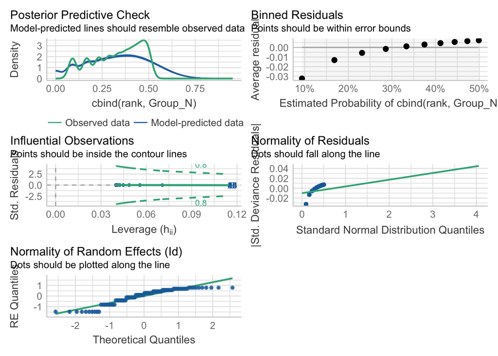

```r
check_model(glmm.rank.bin)
```

#### Poisson GLMM for position within foraging groups

```r
glmm.rank.poiss = glmer(rank ~ 1 + (1|Id),
                        family = "poisson",
                        data = dfsim)
summary(glmm.rank.poiss)
```

```
Generalized linear mixed model fit by maximum likelihood (Laplace
  Approximation) [glmerMod]
 Family: poisson  ( log )
Formula: rank ~ 1 + (1 | Id)
   Data: dfsim

     AIC      BIC   logLik deviance df.resid
 34608.4  34622.8 -17302.2  34604.4     9998

Scaled residuals:
      Min        1Q    Median        3Q       Max
-0.030633 -0.004974  0.001646  0.004199  0.005237

Random effects:
 Groups Name        Variance Std.Dev.
 Id     (Intercept) 0.4764   0.6902
Number of obs: 10000, groups:  Id, 100

Fixed effects:
            Estimate Std. Error z value Pr(>|z|)
(Intercept)  1.51255    0.06928   21.83   <2e-16 ***
---
Signif. codes:  0 '***' 0.001 '**' 0.01 '*' 0.05 '.' 0.1 ' ' 1
```

```r
report_table(glmm.rank.poiss) %>% kable()
```

|  | Parameter | Coefficient | CI | CI_low | CI_high | z | df_error | p | Effects | Group | Std_Coefficient | Std_Coefficient_CI_low | Std_Coefficient_CI_high | Fit |
| --- | --- | --- | --- | --- | --- | --- | --- | --- | --- | --- | --- | --- | --- | --- |
| 1 | (Intercept) | 1.5125501 | 0.95 | 1.376771 | 1.648329 | 21.83363 | Inf | 0 | fixed |  | 1.51255 | 1.376771 | 1.648329 | NA |
| 2 | NA | 0.6902276 | 0.95 | NA | NA | NA | NA | NA | random | Id | NA | NA | NA | NA |
| 3 | NA | NA | NA | NA | NA | NA | NA | NA | NA | NA | NA | NA | NA | NA |
| 4 | AIC | NA | NA | NA | NA | NA | NA | NA | NA | NA | NA | NA | NA | 3.460840e+04 |
| 5 | AICc | NA | NA | NA | NA | NA | NA | NA | NA | NA | NA | NA | NA | 3.460840e+04 |
| 6 | BIC | NA | NA | NA | NA | NA | NA | NA | NA | NA | NA | NA | NA | 3.462282e+04 |
| 7 | R2 (conditional) | NA | NA | NA | NA | NA | NA | NA | NA | NA | NA | NA | NA | 7.052244e-01 |
| 8 | R2 (marginal) | NA | NA | NA | NA | NA | NA | NA | NA | NA | NA | NA | NA | 0.000000e+00 |
| 11 | Sigma | NA | NA | NA | NA | NA | NA | NA | NA | NA | NA | NA | NA | 1.000000e+00 |

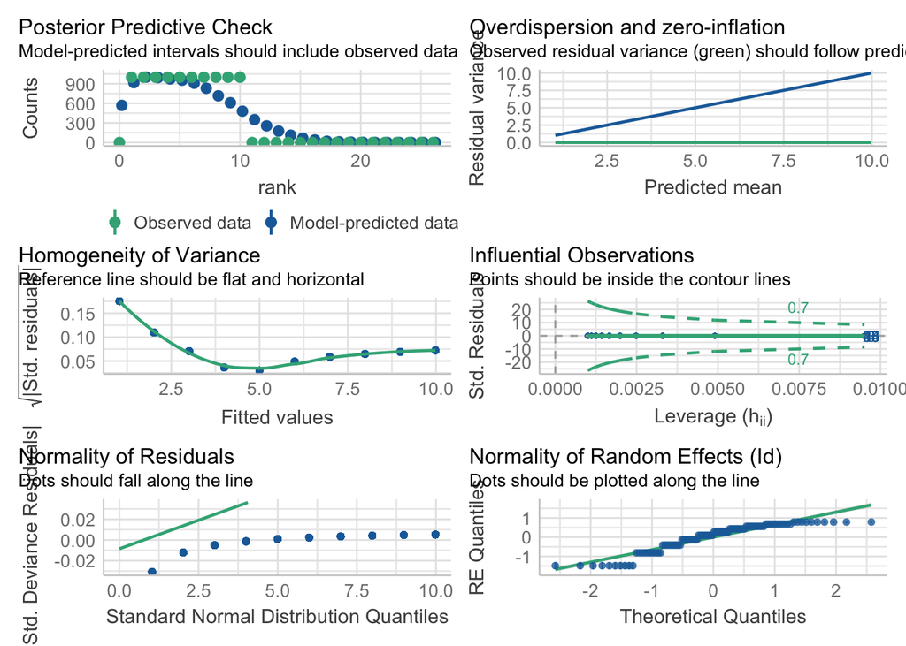

```r
check_model(glmm.rank.poiss)
```

#### Cumulative Link Mixed Model for position within foraging groups

We have two options for CLMMs in R: the `ordinal` package which fits CLMMs in a frequentist framework and `brms` which uses a Bayesian approach. I have a strong preference for working with `brms` given its flexibility and lots of functionality for extracting parameter values and plotting. In contrast, `ordinal` only handles 1 random effect within a model and several utility functions such as `predict()` are not implemented yet.

```r
dfsim$rank.f = as.factor(dfsim$rank)
clmm.rank = clmm(rank.f ~ 1 + (1|Id), data = dfsim, threshold = "equidistant")
clmm.rank
```

```
Cumulative Link Mixed Model fitted with the Laplace approximation

formula: rank.f ~ 1 + (1 | Id)
data:    dfsim

 link  threshold   nobs  logLik  AIC    niter      max.grad
 logit equidistant 10000 -220.31 446.63 401(12553) 3.13e+00

Random effects:
 Groups Name        Variance Std.Dev.
 Id     (Intercept) 14874    122
Number of groups:  Id 100

No Coefficients

Thresholds:
threshold.1     spacing
     -68.22       26.50
```

```r
brms.rank = brm(rank ~ 1 + (1|Id),
                data = dfsim,
                family = "cumulative",
                cores = 4,
                threads = 4,
                iter = 500,
                seed = 42,
                backend = "cmdstanr",
                file = here("outputs/mods/brms.rank"))
```

```r
report_table(brms.rank) %>% kable()
```

|  | Parameter | Median | CI | CI_low | CI_high | pd | Rhat | ESS | Std_Median | Std_Median_CI_low | Std_Median_CI_high | Fit |
| --- | --- | --- | --- | --- | --- | --- | --- | --- | --- | --- | --- | --- |
| 1 | Intercept[1] | -194.771500 | 0.95 | -284.9987000 | -130.7574250 | 1.000 | 1.058004 | 74.93820 | -194.771500 | -284.9987000 | -130.7574250 | NA |
| 2 | Intercept[2] | -121.846500 | 0.95 | -184.0386750 | -77.2297625 | 1.000 | 1.071357 | 54.33070 | -121.846500 | -184.0386750 | -77.2297625 | NA |
| 3 | Intercept[3] | -70.389900 | 0.95 | -119.9223750 | -33.4036200 | 1.000 | 1.082688 | 46.55981 | -70.389900 | -119.9223750 | -33.4036200 | NA |
| 4 | Intercept[4] | -30.046850 | 0.95 | -69.8278100 | 0.4246816 | 0.967 | 1.075347 | 37.56906 | -30.046850 | -69.8278100 | 0.4246816 | NA |
| 5 | Intercept[5] | 0.607018 | 0.95 | -30.0850875 | 30.0031875 | 0.559 | 1.087004 | 31.68301 | 0.607018 | -30.0850875 | 30.0031875 | NA |
| 6 | Intercept[6] | 34.452750 | 0.95 | 0.4793536 | 70.2040600 | 0.981 | 1.089448 | 35.42682 | 34.452750 | 0.4793536 | 70.2040600 | NA |
| 7 | Intercept[7] | 75.545850 | 0.95 | 37.4468850 | 125.7313750 | 1.000 | 1.059517 | 51.64699 | 75.545850 | 37.4468850 | 125.7313750 | NA |
| 8 | Intercept[8] | 127.410000 | 0.95 | 87.5496025 | 193.9234500 | 1.000 | 1.058296 | 85.66555 | 127.410000 | 87.5496025 | 193.9234500 | NA |
| 9 | Intercept[9] | 201.627000 | 0.95 | 145.3978750 | 310.4558250 | 1.000 | 1.030180 | 141.10004 | 201.627000 | 145.3978750 | 310.4558250 | NA |
| 10 | NA | NA | NA | NA | NA | NA | NA | NA | NA | NA | NA | NA |
| 11 | ELPD | NA | NA | NA | NA | NA | NA | NA | NA | NA | NA | -5.5245981 |
| 13 | LOOIC | NA | NA | NA | NA | NA | NA | NA | NA | NA | NA | 11.0491963 |
| 15 | WAIC | NA | NA | NA | NA | NA | NA | NA | NA | NA | NA | 11.0477429 |
| 16 | R2 | NA | NA | NA | NA | NA | NA | NA | NA | NA | NA | 0.9999995 |
| 17 | R2 (marginal) | NA | NA | NA | NA | NA | NA | NA | NA | NA | NA | 0.0000000 |
| 19 | Sigma | NA | NA | NA | NA | NA | NA | NA | NA | NA | NA | 1.0000000 |

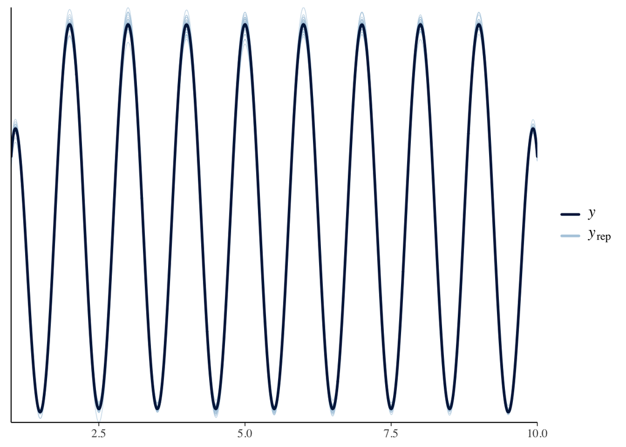

```r
pp_check(brms.rank, ndraws = 100)
```

### 0.5 Comparing the predictive accuracy of the models

We can fit all these models as Bayesian models and compare posterior predictive checks to compare whether one model predicts the data more accurately. We first need to define some reasonable priors and explore prior predictive checks (i.e. how the model might predict data points without having seen the data yet, taking information only from the priors).

```r
bf.bin = bf(rank | trials(Group_N) ~ 1 + (1|Id),
            family = "binomial")

bf.poiss = bf(rank ~ 1 + (1|Id),
              family = "poisson")

bf.clmm = bf(rank ~ 1 + (1|Id),
             family = "cumulative")

priors.bin <-
  # Intercepts priors
  prior(normal(.2, .05), class = Intercept) +
  # Random effects priors (default to exp(1))
  prior(exponential(1), class = sd)

priors.poiss <-
  # Intercepts priors
  prior(normal(1.6, .1), class = Intercept, lb = 0) +
  # Random effects priors
  prior(exponential(1), class = sd)

priors.clmm <-
  # Intercepts priors (default to exp(1))
  prior(normal(0, 1), class = Intercept) +
  # Random effects priors (default to exp(1))
  prior(exponential(1), class = sd)
```

We then apply these priors to the simulated data structure

```r
brms.bin.prior = brm(bf.bin,
                     data = dfsim,
                     prior = priors.bin,
                     sample_prior = "only",
                     warmup = 1000,
                     iter = 2000,
                     seed = 42,
                     cores = 8,
                     threads = threading(8),
                     control = list(adapt_delta = .99,
                                    max_treedepth = 15),
                     backend = "cmdstanr",
                     file_refit = "always",
                     file = here("outputs/mods/brms.bin.prior"))

brms.poiss.prior = brm(bf.poiss,
                       data = dfsim,
                       prior = priors.poiss,
                       sample_prior = "only",
                       warmup = 1000,
                       iter = 2000,
                       seed = 42,
                       cores = 8,
                       threads = threading(8),
                       control = list(adapt_delta = .99,
                                      max_treedepth = 15),
                       backend = "cmdstanr",
                       file_refit = "always",
                       file = here("outputs/mods/brms.poiss.prior"))

brms.clmm.prior = brm(bf.clmm,
                      data = dfsim,
                      prior = priors.clmm,
                      sample_prior = "only",
                      warmup = 1000,
                      iter = 2000,
                      seed = 42,
                      cores = 8,
                      threads = threading(8),
                      control = list(adapt_delta = .99,
                                     max_treedepth = 15),
                      backend = "cmdstanr",
                      file_refit = "always",
                      file = here("outputs/mods/brms.clmm.prior"))
```

And next plot draws from the prior distribution

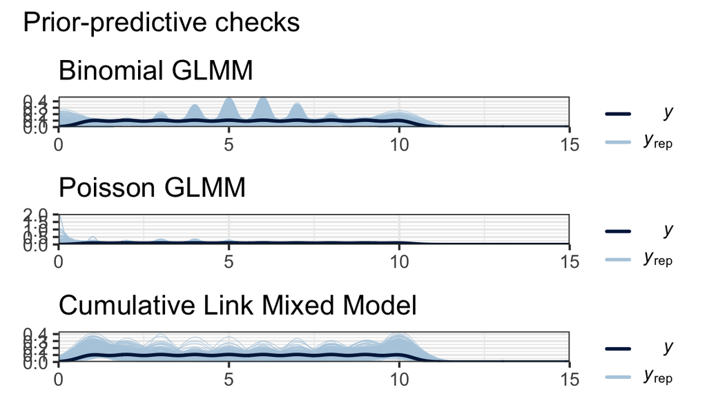

Figure 1: Prior predictive checks for the distribution of individual positions within manta foraging groups

```r
plot.bin = pp_check(brms.bin.prior, ndraws = 500) +
  xlim(0, 15) +
  ggtitle("Binomial GLMM")

plot.poiss = pp_check(brms.poiss.prior, ndraws = 500) +
  xlim(0, 15) +
  ggtitle("Poisson GLMM")

plot.clmm = pp_check(brms.clmm.prior, ndraws = 500) +
  xlim(0, 15) +
  ggtitle("Cumulative Link Mixed Model")

plot.priorpcheck = (plot.bin / plot.poiss / plot.clmm) +
  plot_annotation("Prior-predictive checks") &
  theme_bw(14)
plot.priorpcheck
```

We can already spot some potential issues! Both binomial and Poisson GLMMs predict ranks of 0, which is impossible given our data structure. The cumulative link mixed model seems to fit the data more correctly instead.

Using the same priors, we now fit these models to the simulated data

```r
brms.bin = brm(bf.bin,
                     data = dfsim,
                     prior = priors.bin,
                     warmup = 5000,
                     iter = 6000,
                     seed = 42,
                     cores = 8,
                     threads = threading(8),
                     control = list(adapt_delta = .99,
                                    max_treedepth = 15),
                     backend = "cmdstanr",
                     file_refit = "always",
                     file = here("outputs/mods/brms.bin"))

brms.poiss = brm(bf.poiss,
                       data = dfsim,
                       prior = priors.poiss,
                       warmup = 5000,
                       iter = 6000,
                       seed = 42,
                       cores = 8,
                       threads = threading(8),
                       control = list(adapt_delta = .99,
                                      max_treedepth = 15),
                       backend = "cmdstanr",
                       file_refit = "always",
                       file = here("outputs/mods/brms.poiss"))

brms.clmm = brm(bf.clmm,
                      data = dfsim,
                      prior = priors.clmm,
                      warmup = 5000,
                      iter = 6000,
                      seed = 42,
                      cores = 8,
                      threads = threading(8),
                      control = list(adapt_delta = .99,
                                     max_treedepth = 15),
                      backend = "cmdstanr",
                      file_refit = "always",
                      file = here("outputs/mods/brms.clmm"))
```

And compare predictive checks based on draws from the posterior distribution

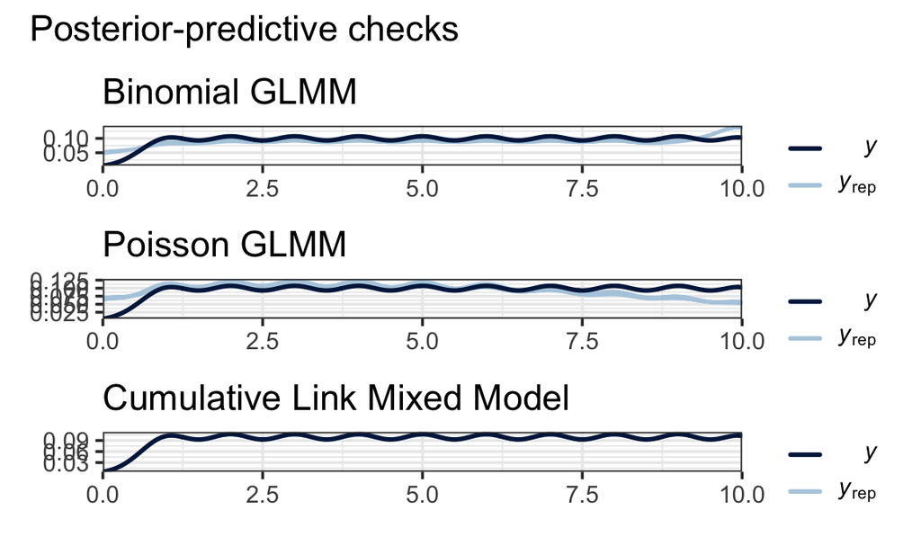

Figure 2: Posterior predictive checks for the distribution of individual positions within manta foraging groups

```r
plot.bin = pp_check(brms.bin, ndraws = 500) +
  xlim(0, 10) +
  ggtitle("Binomial GLMM")

plot.poiss = pp_check(brms.poiss, ndraws = 500) +
  xlim(0, 10) +
  ggtitle("Poisson GLMM")

plot.clmm = pp_check(brms.clmm, ndraws = 500) +
  xlim(0, 10) +
  ggtitle("Cumulative Link Mixed Model")


plot.ppcheck = (plot.bin / plot.poiss / plot.clmm) +
  plot_annotation("Posterior-predictive checks") &
  theme_bw(14)
plot.ppcheck
```

The issues noted above persist with the simulated data. We now to figure out how much of an issue this discrepancy might be in the context of estimating individual differences in individual position within foraging groups. There are also a number of convergence issues with the binomial and Poisson approaches that we don’t encounter with the CLMM model (see `R\test.brms.R` file for the full report) .

#### Estimation of among-individual variance

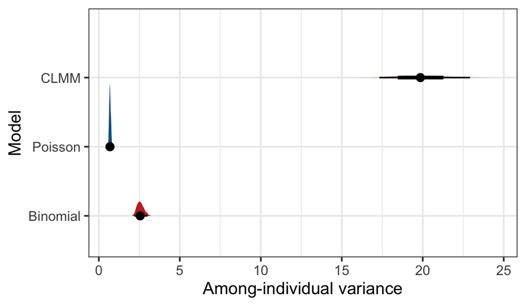

Figure 3: Among-individual variance estimates compared among three types of GLMMs for individual position in foraging groups

```r
Vi.bin = brms.bin %>%
  spread_draws(sd_Id__Intercept)

Vi.poiss = brms.poiss %>%
  spread_draws(sd_Id__Intercept)

Vi.clmm = brms.clmm %>%
  spread_draws(sd_Id__Intercept)

df.Vi = data.frame(
  Vi = c(Vi.bin$sd_Id__Intercept,
         Vi.poiss$sd_Id__Intercept,
         Vi.clmm$sd_Id__Intercept),
  Mod = factor(c(rep("Binomial", length(Vi.bin$sd_Id__Intercept)),
                    rep("Poisson", length(Vi.poiss$sd_Id__Intercept)),
                 rep("CLMM", length(Vi.clmm$sd_Id__Intercept))),
                  levels = c("Binomial", "Poisson", "CLMM")))

plot.Vi = df.Vi %>%
  ggplot(aes(x = Vi, y = Mod, fill = Mod)) +
  stat_halfeye() +
  scale_fill_wsj() +
  xlab("Among-individual variance") +
  ylab("Model") +
  theme_bw(14) +
  theme(legend.position = "none")
plot.Vi
```

As we can see, the variances have little in common between the three models. An added difficulty is that have a firm grasp on what the simulated variance *ought* to be. Individuals were given a value sampled from a $Normal(0, 1)$ distribution but were then ranked at each observation. We can calculate the variance for mean individual rank as a proxy for the true among-individual variance though

```r
dfsim %>%
  group_by(Id, Obs) %>%
  mutate(mean_rank = mean(rank)) %>%
  ungroup() %>%
  summarise(Vi = var(mean_rank))
```

```
# A tibble: 1 × 1
     Vi
  <dbl>
1  8.25
```

We may also ask how accurate the random effect values for each individual are compared to our simulation.

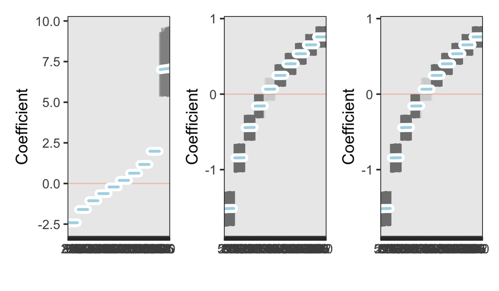

```r
p1 = plot_coefficients(brms.bin, ranef = TRUE, which_ranef = "Id")
p2 = plot_coefficients(brms.poiss, ranef = TRUE, which_ranef = "Id")
p3 = plot_coefficients(brms.poiss, ranef = TRUE, which_ranef = "Id")

(p1 + p2 + p3 ) & theme_bw(14)
```

As we can see, the random effects are expressed on very different scales, making comparisons difficult!

### 0.6 Conclusions on best models for position within group

There is a clear advantage for the CLMM model which performs much better than the binomial or Poisson GLMMs. However, estimating the repeatability for this class of model remains tricky! With non-Gaussian GLMMs, the residual variance is not a statistical parameter estimated from the model, but rather depends on the link function used and the overdispersion type used to fit the model. These issues are now well-resolved for binomial, Poisson and Gamma distribution. However, there is no guidance, to my knowledge, in how to calculate the residual variance with CLMMs. Given these limitations, it seems much more appropriate to compare variability among and within individuals using the leading/following data rather than relying on an individual’s exact position within the group. This should give qualitatively equivalent data on whether some individuals are more likely to position themselves at the front of the foraging chain and therefore seems the much wiser option!

### 0.7 Comparing repeatability and variance components between groups

I focus here in the leading/following behaviors as they are much more consistent with a binomial GLMM. For convenience, I simply allocated individuals to male or female categories at random and do not assume any differences among sexes.

```r
# Make a fake sex column where half individuals get assigned as females and the other half as males
ID$Sex <- as.factor(c(rep("F", nrow(ID)/2),
                      rep("M", nrow(ID)/2)))
dfsim = merge(dfsim, ID)
```

#### Estimate repeatability by sex

```r
rpt.R.f = rpt(formula = lead ~ 1 + (1|Id),
            grname = "Id",
            datatype = "Binary",
            data = subset(dfsim, Sex == "F"))
rpt.R.m = rpt(formula = lead ~ 1 + (1|Id),
            grname = "Id",
            datatype = "Binary",
            data = subset(dfsim, Sex == "M"))
saveRDS(rpt.R.f, here("outputs/mods/rpt.R.f.rds"))
saveRDS(rpt.R.m, here("outputs/mods/rpt.R.m.rds"))
```

This code store the values for repeatability into an `rpt` object. We can access the numeric values of each bootstrap from within the `R_boot` column and plot the distribution or the distribution for the difference between each sexes.

**Note**

```r
# Inspect rpt objects
summary(rpt.R.f)
```

```
Repeatability estimation using glmer method

Call = rpt(formula = lead ~ 1 + (1 | Id), grname = "Id", data = subset(dfsim, Sex == "F"), datatype = "Binary")

Data: 5000 observations
----------------------------------------

Id (50 groups)

Repeatability estimation overview:
          R       SE   2.5%  97.5% P_permut
Org   0.809 5.83e+02  0.259   2543       NA
Link  0.999 1.19e-03  0.997      1       NA


Bootstrapping:
          N    Mean Median   2.5%  97.5%
Org    1000 229.197  0.360  0.259   2543
Link   1000   0.999  0.999  0.997      1

Permutation test:
          N   Mean Median   2.5%  97.5% P_permut
Org       1     NA     NA     NA     NA       NA
Link      1     NA     NA     NA     NA       NA

Likelihood ratio test:
logLik full model = -8.883293
logLik red. model = -1625.415
D  = 3230, df = 1, P = 0

----------------------------------------
```

```r
summary(rpt.R.m)
```

```
Repeatability estimation using glmer method

Call = rpt(formula = lead ~ 1 + (1 | Id), grname = "Id", data = subset(dfsim, Sex == "M"), datatype = "Binary")

Data: 5000 observations
----------------------------------------

Id (50 groups)

Repeatability estimation overview:
          R       SE   2.5%  97.5% P_permut
Org   0.809 5.53e+02  0.258   2542       NA
Link  0.999 1.11e-03  0.997      1       NA


Bootstrapping:
          N    Mean Median   2.5%  97.5%
Org    1000 216.128  0.359  0.258   2542
Link   1000   0.999  0.999  0.997      1

Permutation test:
          N   Mean Median   2.5%  97.5% P_permut
Org       1     NA     NA     NA     NA       NA
Link      1     NA     NA     NA     NA       NA

Likelihood ratio test:
logLik full model = -8.883293
logLik red. model = -1625.415
D  = 3230, df = 1, P = 0

----------------------------------------
```

#### Estimate among and within-individual variance by sex

To get the among and within-individual variances, we need to rerun the `rpt` function, this time specifying that we want to extract the variance rather than the repeatablities. This can be done by setting the ratio argument to `ratio = F`

```r
rpt.V.f <- rpt(formula = lead ~ 1 + (1|Id),
               grname = c("Id", "Fixed", "Residual"),
               datatype = c("Binary"),
               data = subset(dfsim, Sex == "F"),
               ratio = FALSE)
rpt.V.m <- rpt(formula = lead ~ 1 + (1|Id),
               grname = c("Id", "Fixed", "Residual"),
               datatype = "Binary",
               data = subset(dfsim, Sex == "M"),
               ratio = FALSE)

saveRDS(rpt.V.f, here("outputs/mods/rpt.V.f.rds"))
saveRDS(rpt.V.m, here("outputs/mods/rpt.V.m.rds"))
```

#### Combining all elements into a nice plot

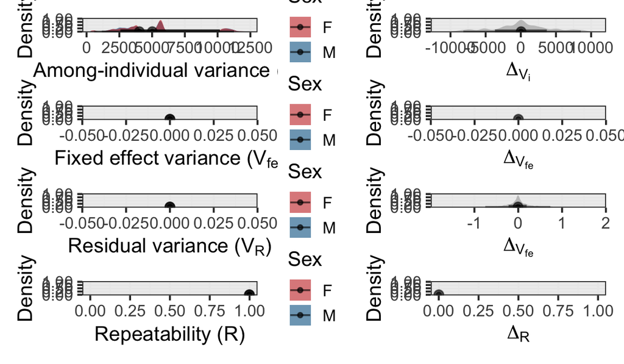

Figure 5: Variance components and difference in variances compared among sexes

```r
# Store all vectors of bootstrapped values
Vi_f <- rpt.V.f$R_boot_link$Id
Vi_m <- rpt.V.m$R_boot_link$Id
Vfe_f <- rpt.V.f$R_boot_link$Fixed
Vfe_m <- rpt.V.m$R_boot_link$Fixed
VR_f <- rpt.V.f$R_boot_link$Residual
VR_m <- rpt.V.m$R_boot_link$Residual
R_f <- rpt.R.f$R_boot_link$Id
R_m <- rpt.R.m$R_boot_link$Id

df <- data.frame(Vi = c(Vi_f, Vi_m),
                 Vfe = c(Vfe_f, Vfe_m),
                 VR = c(VR_f, VR_m),
                 R = c(R_f, R_m),
                 Sex = c(rep("F", length(Vi_f)),
                         rep("M", length(Vi_m))))
# Store effect sizes
df.2  <- data.frame(delta_Vi = Vi_f - Vi_m,
                    delta_Vfe = Vfe_f - Vfe_m,
                    delta_VR = VR_f - VR_m,
                    delta_R = R_f - R_m)


p1 = df %>%
  ggplot(aes(x = Vi, fill = Sex)) +
  stat_halfeye(alpha = .6) +
  scale_fill_wsj() +
  xlab(bquote("Among-individual variance ("*V[i]*")")) +
  ylab("Density") +
  theme_bw(14)
delta.p1 = df.2 %>%
  ggplot(aes(x = delta_Vi)) +
  stat_halfeye(alpha = .6) +
  xlab(bquote(Delta[V[i]])) +
  ylab("Density") +
  theme_bw(14)
p1 = p1 + delta.p1

p2 = df %>%
  ggplot(aes(x = Vfe, fill = Sex)) +
  stat_halfeye(alpha = .6) +
  scale_fill_wsj() +
  xlab(bquote("Fixed effect variance ("*V[fe]*")")) +
  ylab("Density") +
  theme_bw(14)
delta.p2 = df.2 %>%
  ggplot(aes(x = delta_Vfe)) +
  stat_halfeye(alpha = .6) +
  xlab(bquote(Delta[V[fe]])) +
  ylab("Density") +
  theme_bw(14)
p2 = p2 + delta.p2


p3 = df %>%
  ggplot(aes(x = Vfe, fill = Sex)) +
  stat_halfeye(alpha = .6) +
  scale_fill_wsj() +
  xlab(bquote("Residual variance ("*V[R]*")")) +
  ylab("Density") +
  theme_bw(14)
delta.p3 = df.2 %>%
  ggplot(aes(x = delta_VR)) +
  stat_halfeye(alpha = .6) +
  xlab(bquote(Delta[V[fe]])) +
  ylab("Density") +
  theme_bw(14)
p3 = p3 + delta.p3

p4 = df %>%
  ggplot(aes(x = R, fill = Sex)) +
  stat_halfeye(alpha = .6) +
  scale_fill_wsj() +
  xlim(0, 1) +
  xlab(bquote("Repeatability (R)")) +
  ylab("Density") +
  theme_bw(14)
delta.p4 = df.2 %>%
  ggplot(aes(x = delta_R)) +
  stat_halfeye(alpha = .6) +
  xlim(0, 1) +
  xlab(bquote(Delta[R])) +
  ylab("Density") +
  theme_bw(14)
p4 = p4 + delta.p4

plot_var_R = p1 / p2 / p3 / p4
plot_var_R
```

The output looks a little janky, but that’s not surprising given that we’ve simulated data with no fixed effects. In our case, the only source of variation comes from the amon-individual preferences for being at the front or the back of the group. Hence, the variation explained by fixed effects and residuals reduces to 0 and repeatability equals 1 in our case.